# Practica 4

Alejandro Caceres

2024-03-26

## Poisson (variable discreta)

El número de llamadas en una centralita sigue un modelo de poisson con $\lambda=25$.

Dibujemos la función de masa de probabilidad

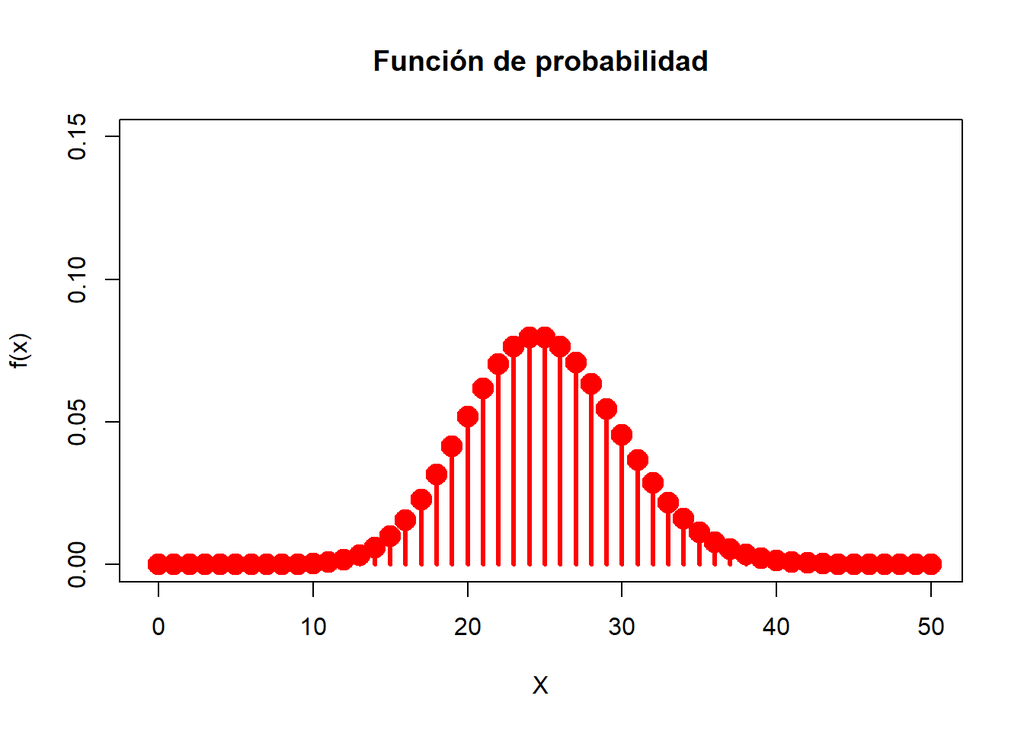

```r
x2 <- 0:50
f2 <- dpois(x2,lambda=25)

plot(x2, f2, type="h", col="red", lwd=3, main="Función de probabilidad", xlab="X", ylab="f(x)",
     xlim=c(-0.5,50),
     ylim=c(0,0.15))

points(x2, f2, col="red", lwd=8)
```

- ¿Cuál es la probabilidad de recibir 10 llamadas?

```r
dpois(10,25)
```

```
## [1] 0.000364985
```

- ¿Cuál es la probabilidad de recibir 30 llamadas?

```r
dpois(30,25)
```

```
## [1] 0.04541279
```

Dibujemos la funcion de distribución

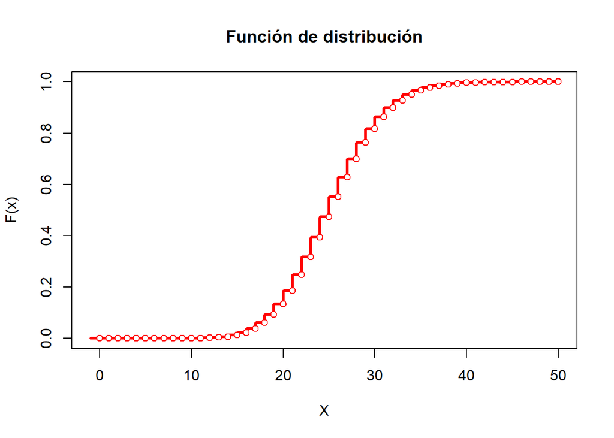

```r
x2 <- 0:50
F2 <- ppois(x2,lambda=25)
plot(c(-1,x2,50), c(0,F2,1), type="s", col="red", lwd=3, main="Función de distribución", xlab="X",
     ylab="F(x)")

points(x2, c(0,F2[-50]),
       col="red",
       pch=21,
       bg="white")
```

- ¿Cuál es la probabilidad de recibir como mucho 30 llamadas? $P(X \leq 30)$

```r
ppois(30,25)
```

```
## [1] 0.8633089
```

- ¿Cuál es la probabilidad de recibir como minimo 30 llamadas? $P(X \geq 30)$

```r
1-ppois(29,25)
```

```
## [1] 0.1821039
```

## Exponencial (variable continua)

El **tiempo** entre dos llamadas sigue una densidad de probabilidad exponencial con $\lambda=25$

Dibujemos la densiad de probabilidad

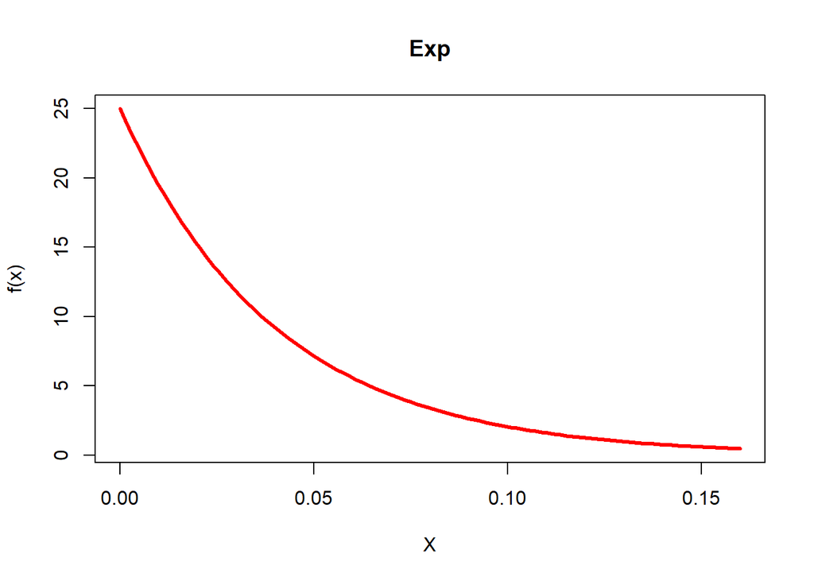

```r
lambda = 25
curve(dexp(x, rate=lambda), xlim = c(0, 4/lambda), col="red",
      lwd=3, main="Exp", xlab="X", ylab="f(x)")
```

- ¿Cuál es la probabilidad de que pase un tiempo de 0.033 entre dos llamadas?

$P(X=0.033)=0$

- ¿Cuál es la probabilidad de que pase un tiempo de al menos 0.052 entre dos llamadas?

$P(X>0.052)= 1-F(0.052)$

Dibujemos la funcion de distribución

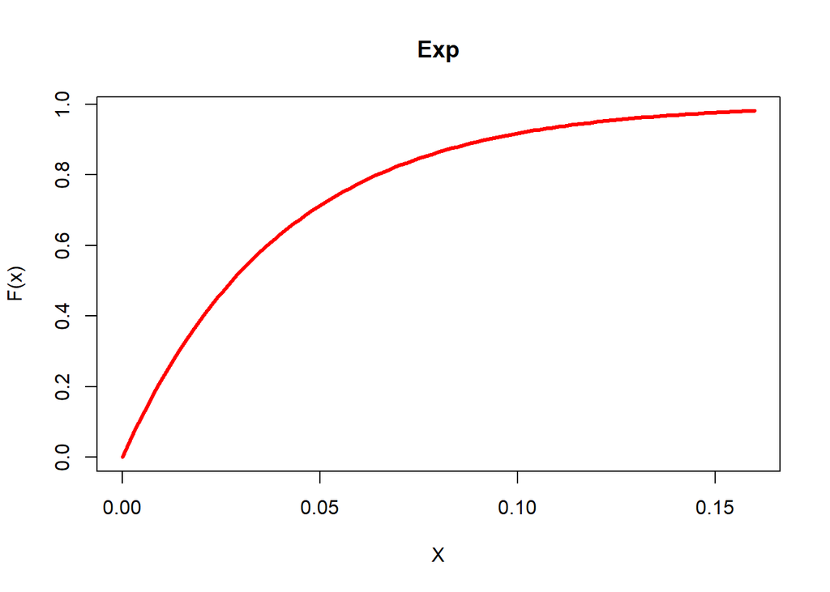

```r
curve(pexp(x, rate=lambda), xlim = c(0, 4/lambda), col="red",
      lwd=3, main="Exp", xlab="X", ylab="F(x)")
```

```r
1-pexp(0.052, 25)
```

```
## [1] 0.2725318
```

- ¿Cuál tiempo de espera máximo que comprende un 75% de llamadas?

```r
qexp(0.75, 25)
```

```
## [1] 0.05545177
```

- Hgamos 500000 simulaciones del tiempo entre dos llamadas, y calculemos su media

```r
simul <- rexp(500000,25)
mean(simul)
```

```
## [1] 0.03998012
```

El valor esperado de una variable exponencial es

```r
1/lambda
```

```
## [1] 0.04
```